# chapter4.Rmd

## 4. Standardizing the data set

Before we can easily compare the different variables, we shall scale the values, so they are compatable with one another.

```r
boston_scaled <- scale(Boston)
```

```r
summary(boston_scaled)
```

```
##       crim                 zn               indus
##  Min.   :-0.419367   Min.   :-0.48724   Min.   :-1.5563
##  1st Qu.:-0.410563   1st Qu.:-0.48724   1st Qu.:-0.8668
##  Median :-0.390280   Median :-0.48724   Median :-0.2109
##  Mean   : 0.000000   Mean   : 0.00000   Mean   : 0.0000
##  3rd Qu.: 0.007389   3rd Qu.: 0.04872   3rd Qu.: 1.0150
##  Max.   : 9.924110   Max.   : 3.80047   Max.   : 2.4202
##       chas              nox                rm               age
##  Min.   :-0.2723   Min.   :-1.4644   Min.   :-3.8764   Min.   :-2.3331
##  1st Qu.:-0.2723   1st Qu.:-0.9121   1st Qu.:-0.5681   1st Qu.:-0.8366
##  Median :-0.2723   Median :-0.1441   Median :-0.1084   Median : 0.3171
##  Mean   : 0.0000   Mean   : 0.0000   Mean   : 0.0000   Mean   : 0.0000
##  3rd Qu.:-0.2723   3rd Qu.: 0.5981   3rd Qu.: 0.4823   3rd Qu.: 0.9059
##  Max.   : 3.6648   Max.   : 2.7296   Max.   : 3.5515   Max.   : 1.1164
##       dis               rad               tax             ptratio
##  Min.   :-1.2658   Min.   :-0.9819   Min.   :-1.3127   Min.   :-2.7047
##  1st Qu.:-0.8049   1st Qu.:-0.6373   1st Qu.:-0.7668   1st Qu.:-0.4876
##  Median :-0.2790   Median :-0.5225   Median :-0.4642   Median : 0.2746
##  Mean   : 0.0000   Mean   : 0.0000   Mean   : 0.0000   Mean   : 0.0000
##  3rd Qu.: 0.6617   3rd Qu.: 1.6596   3rd Qu.: 1.5294   3rd Qu.: 0.8058
##  Max.   : 3.9566   Max.   : 1.6596   Max.   : 1.7964   Max.   : 1.6372
##      black             lstat              medv
##  Min.   :-3.9033   Min.   :-1.5296   Min.   :-1.9063
##  1st Qu.: 0.2049   1st Qu.:-0.7986   1st Qu.:-0.5989
##  Median : 0.3808   Median :-0.1811   Median :-0.1449
##  Mean   : 0.0000   Mean   : 0.0000   Mean   : 0.0000
##  3rd Qu.: 0.4332   3rd Qu.: 0.6024   3rd Qu.: 0.2683
##  Max.   : 0.4406   Max.   : 3.5453   Max.   : 2.9865
```

[output not shown]

From this new scaled variable we can see that all the variable values range between -10 and 10. This will probably lead to an easier way to compare the different variables.

Now I shall create a chategorical variable of the crime rates in Boston. I will do this, because it is not possible to use the numerical values in some of the codes that we have to make so we get the wanted results.

```r
scaled_crim <-boston_scaled$crim
```

Now I need to use the quantiles as break points in the variable. The quantiles are 0%, 25%, 50%, 75% and 100%. This makes it easier to understand how the values are distributed in a specific variable. The variable that I am using is the ‘crim’ variable.

```
##           0%          25%          50%          75%         100%
## -0.419366929 -0.410563278 -0.390280295  0.007389247  9.924109610
```

As we can see, I have created breaking points at the quantlies. So from these we can interpet that half of the variable values are between values -0,419 and -0,390. So we can conclude that there isn’t a very big difference between the first 50% of the data. The big difference is found between the last 25% (75%-100%), where the values are distributed between 0,00738 and 9,9241. I would interpet this as there being a few towns with extremely high crime rates in comparison to other towns.

Next I will create a new variable ‘crime’ that consists of the scaled crim values, its breaks consists of the quartiles, and we are labeling 4 different groupings on the rates of crimes. The groupings are low-, medium low-, medium high- and very high crime rates.

```r
crime <- cut(scaled_crim, breaks = bins, include.lowest = TRUE, labels = c("low", "med_low", "med_high", "high"))
```

```r
table(crime)
```

```
## crime
##      low  med_low med_high     high
##      127      126      126      127
```

Next I will have to drop the old crime rate (‘crim’) variable from the data set. This I will do, because the new crime rate is more sufficient to my needs of analysis.

```r
boston_scaled <- dplyr::select(boston_scaled, -crim)
```

```r
boston_scaled <- data.frame(boston_scaled, crime)
```

Next I shall divide the scaled_boston data into two different data sets; ‘test’ and ‘train’. But before I can divide the data to two new data sets, I need to figure out how many rows the boston_scaled variable has. The number of rows is saved as he variable ‘n’.

```r
n <-nrow(boston_scaled)
```

Next I need to take a sample of the data, and in the task 80% ov the data will go to the ‘train’ data set, so we need a sample that cover 80% of the scaled_boston data set. This variable shall be named ind.

```r
ind <- sample(n,  size = n * 0.8)
```

Now we can divide the scaled_data set into the two new data sets ‘train’ and ‘test’

```r
train <- boston_scaled[ind,]
```

```r
test <- boston_scaled[-ind,]
```

## 5. Linear discriminant analysis: train set

In the linear discriminant analysis I will be looking at the target variable crime, and all the other values are predictors of the crime value. We can also see the predictor variables being grouped by the labels low, med_low, med_high and high. At the bottom we can also find the coefficients of the linear discriminants.

```r
lda.fit
```

```
## Call:
## lda(crime ~ ., data = train)
##
## Prior probabilities of groups:
##       low   med_low  med_high      high
## 0.2450495 0.2500000 0.2500000 0.2549505
##
## Group means:
##                   zn      indus          chas        nox         rm
## low       0.95304181 -0.9369914 -0.1132543107 -0.8853128  0.4587638
## med_low  -0.09943559 -0.2571161  0.0005392655 -0.5156685 -0.1959586
## med_high -0.39214634  0.1493520  0.2734075986  0.3412440  0.1088283
## high     -0.48724019  1.0170891 -0.1194319712  1.0780039 -0.4186061
##                 age        dis        rad        tax     ptratio
## low      -0.8491347  0.8314370 -0.6976546 -0.7569282 -0.49735465
## med_low  -0.3567895  0.3411572 -0.5418150 -0.4327837 -0.04028589
## med_high  0.4137251 -0.3412095 -0.4019522 -0.3242199 -0.29639185
## high      0.8286338 -0.8586601  1.6384176  1.5142626  0.78111358
##                black         lstat        medv
## low       0.37890775 -0.7682886593  0.55831383
## med_low   0.35122000 -0.1001312533 -0.05459471
## med_high  0.06770823 -0.0006230698  0.16523342
## high     -0.66554167  0.9033963079 -0.69796036
##
## Coefficients of linear discriminants:
##                 LD1         LD2         LD3
## zn       0.13464753  0.81532812 -0.91330031
## indus    0.05923004 -0.34945208  0.31756036
## chas    -0.07772918 -0.13320308  0.06786737
## nox      0.38339479 -0.63940498 -1.12085830
## rm      -0.08736011 -0.07252264 -0.18194829
## age      0.20783048 -0.33448598 -0.41632772
## dis     -0.05207543 -0.42941770  0.28250566
## rad      3.17889316  0.84743583 -0.30361944
## tax     -0.04478752  0.04265725  0.84396067
## ptratio  0.13045097  0.05393263 -0.18217579
## black   -0.11770401  0.03091145  0.22561617
## lstat    0.25213844 -0.22097821  0.38947919
## medv     0.17914514 -0.32908334 -0.20301735
##
## Proportion of trace:
##    LD1    LD2    LD3
## 0.9493 0.0366 0.0142
```

Next we want to visualize the distribution of these different variables are distributed. The different labeling chategorize are coded in different colors. The low value is black, med_low is red, med_high is green and the high values are blue. The different variables are also coded in ted, and they also have arrows that point in what direction they move.

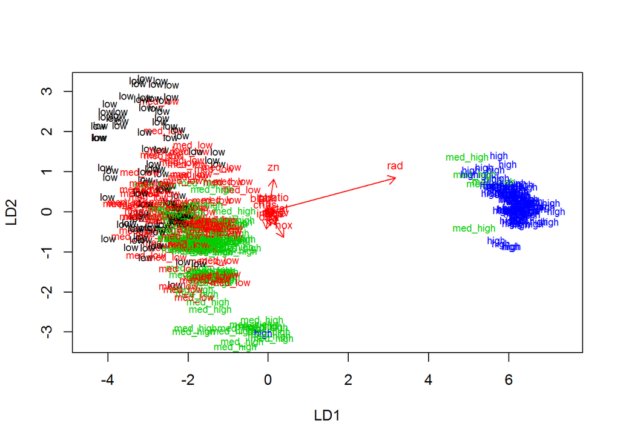

## 6. Predicting the classes

Next task is to predict classes. This I will do with the test data frame. The prediction is made to evaluate what kind of values a specific variable is supposed to give, based upon some values.

```r
table(correct = correct_classes, predicted = lda.pred$class)
```

```
##           predicted
## correct    low med_low med_high high
##   low       17      10        1    0
##   med_low    7      14        4    0
##   med_high   0       4       20    1
##   high       0       0        0   24
```

Here we can compare between the actual values and the predicted values and how much they differ from each other.

## 7. Reloading the Boston data set

Reloading and scaling the Boston data set

```r
summary(dist_eu)
```

```
##    Min. 1st Qu.  Median    Mean 3rd Qu.    Max.
##  0.1343  3.4620  4.8240  4.9110  6.1860 14.4000
```

Here we have the distances between the calcultations in the scaled Boston data frame.

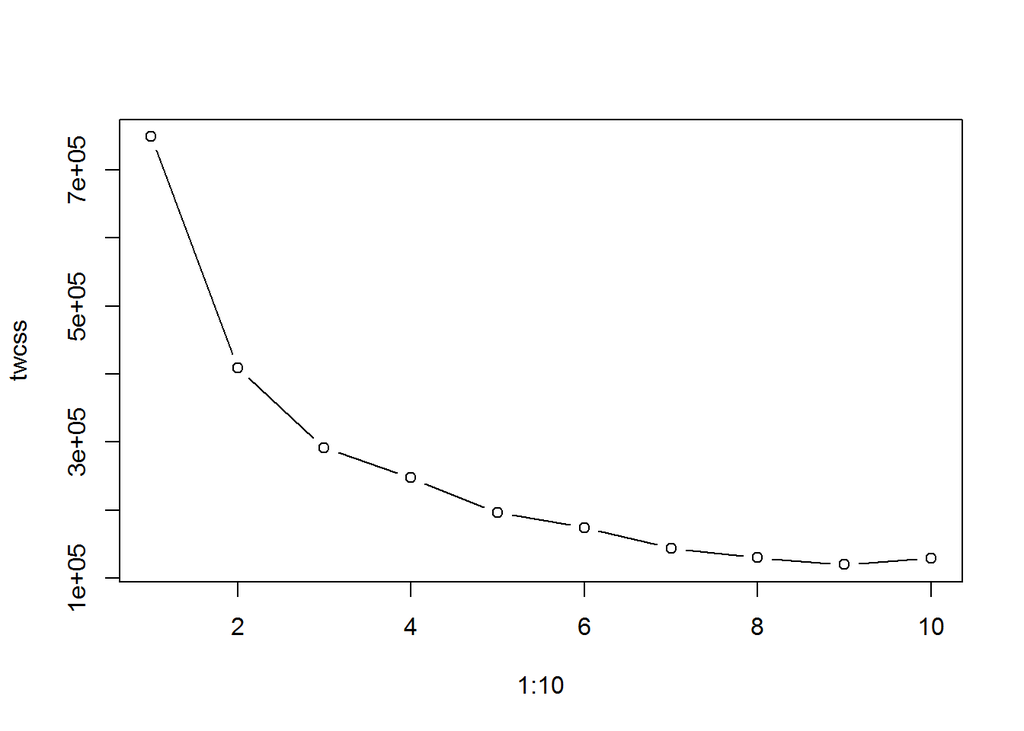

From this image I shall conclude what the best number of centers I will use in the visualizing stage of the material. So I will choose the number 3, because this image tilts a little at the number 3.

### Visualizing the distribution

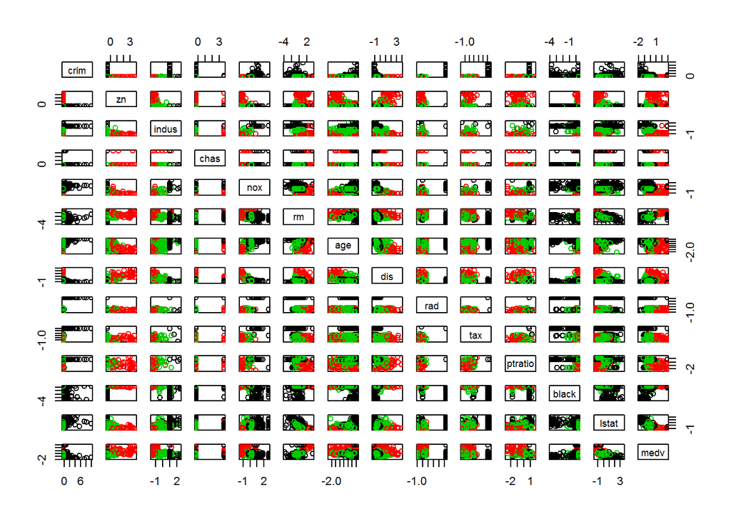